# Single-cell RNA-seq: young vs aged human skin

Example report made with Claude and the BRC plugin

Author

Bioinformatics Resource Center, Rockefeller University

Published

November 10, 2026

**NoteAbout this report**

Everything here was produced in a single Claude session with the **BRC plugin**, which gives Claude access to single-cell datasets hosted by the BRC (here 76 datasets) and tools to query and plot them. The prompts used are shown in each section.

**Data:** public dataset GSE130973, human skin from 2 young and 3 older donors. Solé-Boldo et al. (2020) *Single-cell transcriptomes of the human skin reveal age-related loss of fibroblast priming.* Commun Biol 3:188. [doi:10.1038/s42003-020-0922-4](https://doi.org/10.1038/s42003-020-0922-4)

## 1. What’s in the dataset?

> *“Load the young vs aged skin dataset and give me a QC summary per donor.”*

| Donor | Age | Cells | Median genes per cell | Median UMIs per cell | Median mito % | 95th percentile mito % |
| --- | --- | --- | --- | --- | --- | --- |
| S1 | Young | 2784 | 1194 | 3155 | 2.46 | 4.45 |
| S2 | Young | 2670 | 1082 | 2697 | 2.07 | 4.09 |
| S3 | Old | 3324 | 1492 | 4077 | 1.41 | 2.84 |
| S4 | Old | 2144 | 1133 | 2935 | 2.60 | 4.38 |
| S5 | Old | 4535 | 754 | 1651 | 1.50 | 3.09 |

**What Claude found:** 15,457 cells from 5 donors. Mitochondrial reads are low for every donor (median 1.4-2.6%), so there is no sign of many dying cells. Donor **S5** (old) has the most cells but the fewest genes and UMIs per cell, so its cells were sequenced less deeply. Keep that in mind when comparing ages: with only 2 young and 3 old donors, one donor can drive a difference.

## 2. Clusters and age

> *“Show me the UMAP coloured by cluster, and again by age.”*

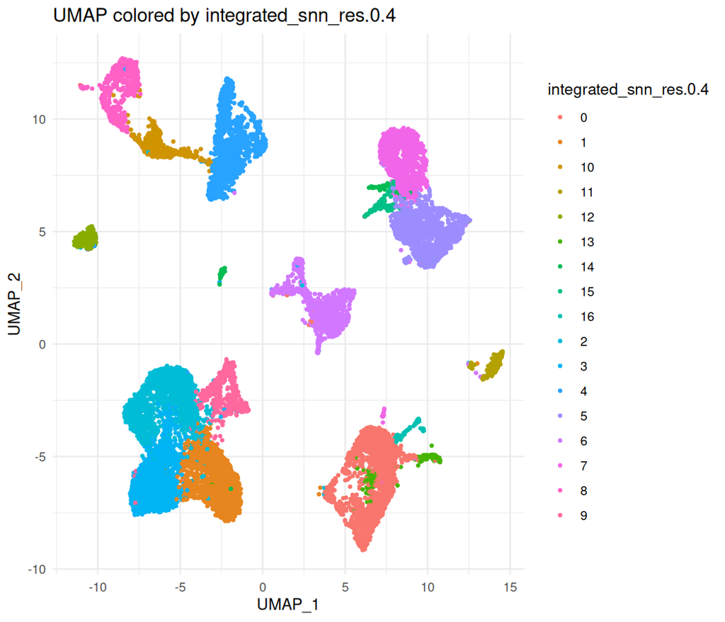

Clusters

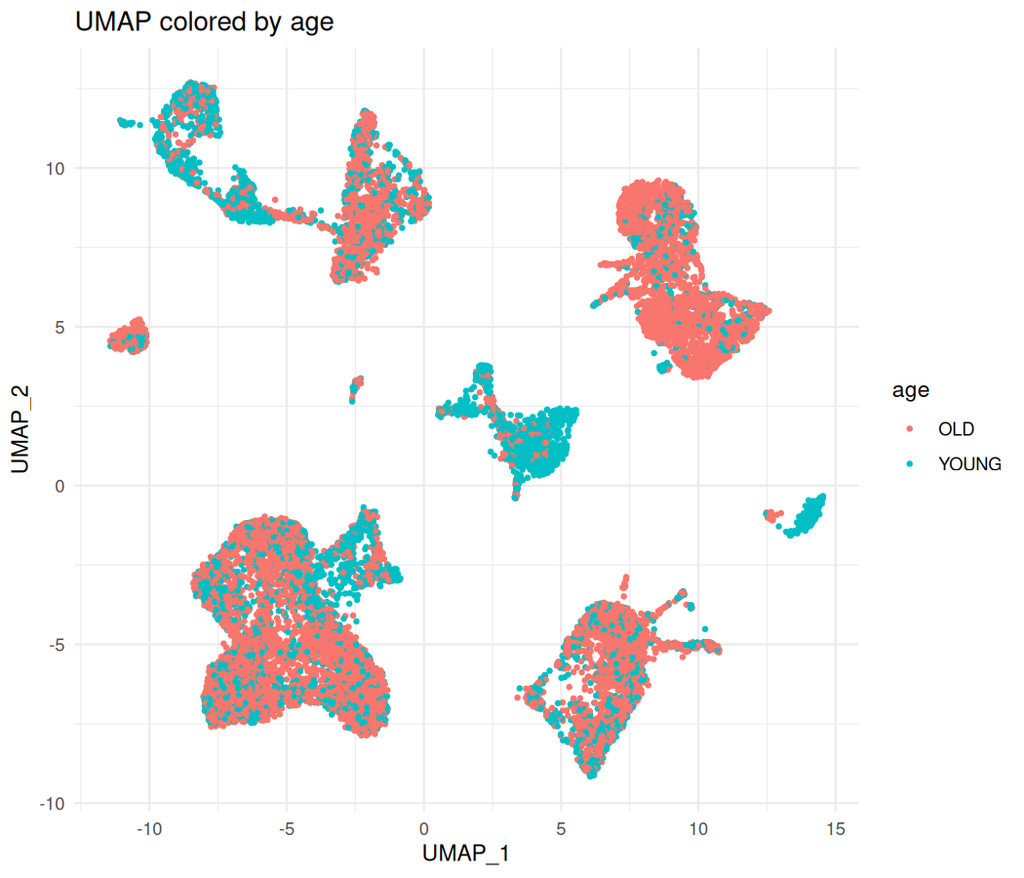

Age

## 3. What cell types are the clusters?

> *“Make a dot plot of skin cell-type markers across the clusters and suggest a cell type for each.”*

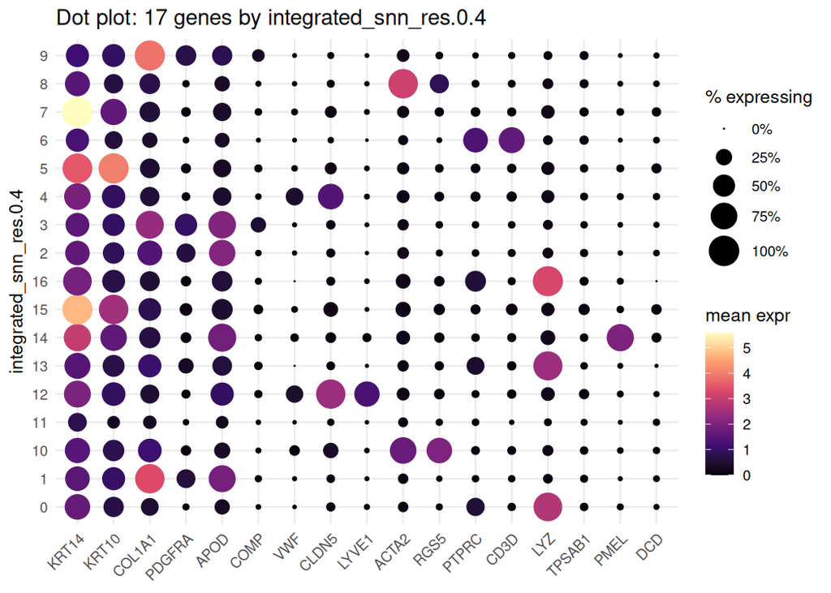

Marker genes by cluster. Dot size = % of cells expressing; colour = mean expression.

| Cluster | Proposed cell type | Marker evidence | Cells |
| --- | --- | --- | --- |
| 0 | Myeloid | LYZ | 1930 |
| 1 | Fibroblasts | COL1A1, APOD | 1886 |
| 2 | Fibroblasts | APOD, COL1A1 | 1793 |
| 3 | Fibroblasts | COL1A1, APOD, PDGFRA | 1675 |
| 4 | Endothelial (vascular) | CLDN5, VWF | 1467 |
| 5 | Keratinocytes | KRT10 (differentiating) | 1399 |
| 6 | T cells | CD3D, PTPRC | 1281 |
| 7 | Keratinocytes | KRT14 (basal) | 1069 |
| 8 | Pericytes / smooth muscle | ACTA2, RGS5 | 722 |
| 9 | Fibroblasts | COL1A1 | 594 |
| 10 | Pericytes / smooth muscle | ACTA2, RGS5 | 498 |
| 11 | Unclear (low quality?) | Few genes per cell; 271 of 310 cells from one donor | 310 |
| 12 | Endothelial (lymphatic) | CLDN5, LYVE1 | 294 |
| 13 | Myeloid | LYZ | 227 |
| 14 | Melanocytes | PMEL | 123 |
| 15 | Keratinocytes | KRT14, KRT10 | 118 |
| 16 | Myeloid | LYZ | 71 |

**What Claude found:** fibroblasts are the largest group (clusters 1, 2, 3 and 9), as expected for a dermis-rich sample, alongside myeloid cells, endothelial cells, keratinocytes, T cells, pericytes and a small melanocyte cluster. **Cluster 11 is suspicious:** its cells express few genes, and almost all of them come from one donor (S2), which looks like a technical artefact rather than a cell type.

**Tip**

These labels are **Claude’s suggestions from a handful of markers**, a starting point, not a final annotation. Check them against the paper and a reference atlas, and ask the BRC if you need a formal annotation.

## 4. Does cell-type composition change with age?

> *“Compare the proportion of each cell type between young and old donors, per donor.”*

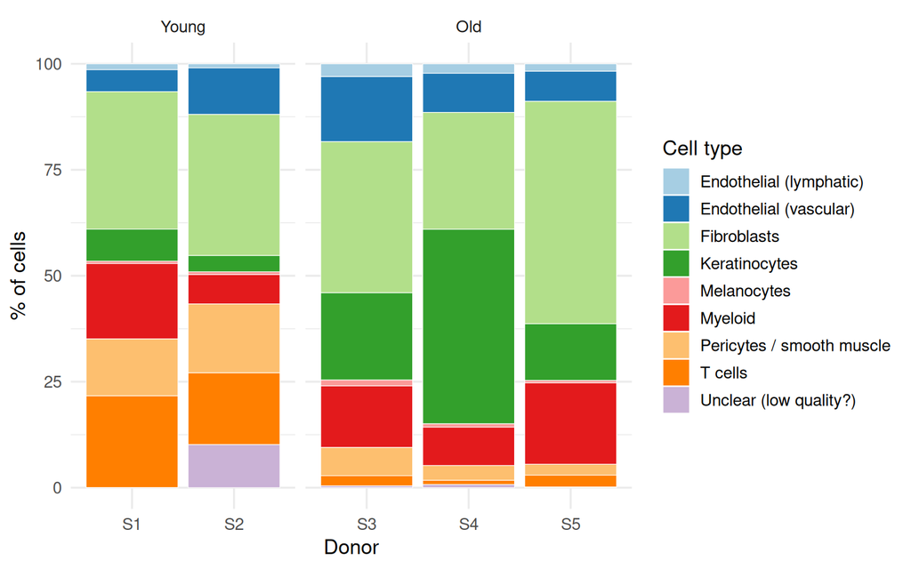

% of each donor’s cells

| celltype | S1 | S2 | S3 | S4 | S5 |
| --- | --- | --- | --- | --- | --- |
| Endothelial (lymphatic) | 1.4 | 1.0 | 3.0 | 2.2 | 1.8 |
| Endothelial (vascular) | 5.2 | 11.0 | 15.3 | 9.2 | 7.1 |
| Fibroblasts | 32.4 | 33.3 | 35.6 | 27.6 | 52.5 |
| Keratinocytes | 7.5 | 3.8 | 20.6 | 45.9 | 13.4 |
| Melanocytes | 0.6 | 0.7 | 1.4 | 0.8 | 0.6 |
| Myeloid | 17.8 | 6.9 | 14.5 | 9.0 | 19.2 |
| Pericytes / smooth muscle | 13.4 | 16.3 | 6.6 | 3.5 | 2.6 |
| T cells | 21.6 | 16.9 | 2.4 | 1.0 | 2.8 |
| Unclear (low quality?) | 0.0 | 10.1 | 0.4 | 0.7 | 0.2 |

**What Claude found:** **T cells** make up 17-22% of the cells from both young donors but only 1-3% of cells from each old donor, a consistent difference in all five donors. Other shifts are driven mainly by single donors: for example, much of keratinocyte cluster 5 comes from old donor S4. Composition depends on how each biopsy was taken and dissociated, so these are leads to follow up, not conclusions.

## What the BRC plugin did

| Step | What you ask | What happens behind the scenes |
| --- | --- | --- |
| Find data | “What single-cell datasets are available?” | Lists the scRNA-seq datasets the BRC hosts |
| Load | “Load the young vs aged skin dataset” | Activates the dataset on the BRC server |
| QC and counts | “QC per donor”, “cells per cluster per donor” | Read-only queries of the cell metadata |
| Plots | “UMAP by age”, “dot plot of markers” | The server draws the plots from the full expression data |
| Markers | “What genes differ between clusters?” | Runs a marker test on the server |
| Report | “Put it all in one report” | Writes this page |

The expression data never leave the BRC server. Claude only sees the summaries and plots it asks for.

**WarningBefore you use results like these**

- Single-cell results depend on choices made upstream: filtering, clustering resolution and integration. The clusters here are the ones supplied with the dataset.
- Cell-level statistics treat thousands of cells as independent, which overstates confidence. Compare donors, not cells, and talk to the BRC about the right test.

*Learn more: [Single-cell RNA-seq (BRC training)](https://rockefelleruniversity.github.io/scRNA-seq/) · Contact: brc@rockefeller.edu*